# Project Python Foundations: FoodHub Data Analysis

### -- Delivery time does not have any outliers.

## Explore the Catogirical Variable

### 4. Obesetvation on Cuisine Type using Counterplot

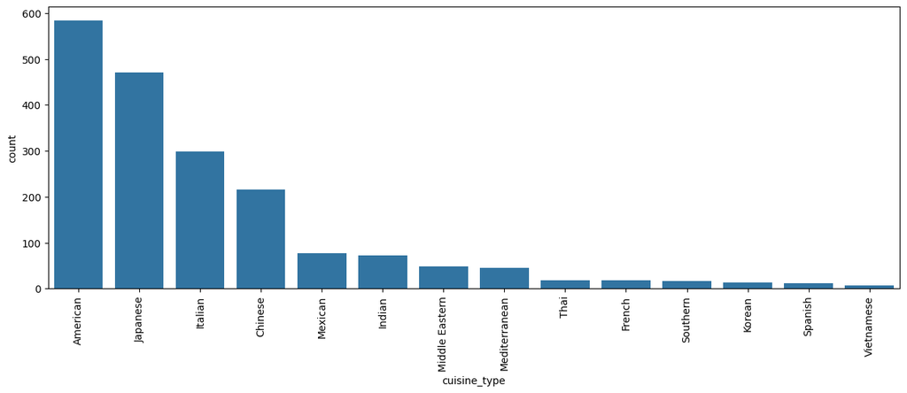

```python
plt.figure(figsize = (15,5))
plt.xticks(rotation = 90)
sns.countplot(data = df, x = 'cuisine_type',order=df['cuisine_type'].value_counts().index);
```

### Countplot observations for Cuisine Types

### -- **Popular Cuisine Types:** Certain cuisine types, such as American, Japanese, and Italian, have significantly higher counts compared to others. These cuisines appear to be more frequently ordered, indicating their popularity among customers.

### -- **Less Popular Cuisine Types:** From the countplot Cuisines from Mexican to Vietnamese have relatively lower orders.

### 5. Obesetvation on Rating using Counterplot

```python
# Check the unique values
df['rating'].nunique()
```

```
4
```

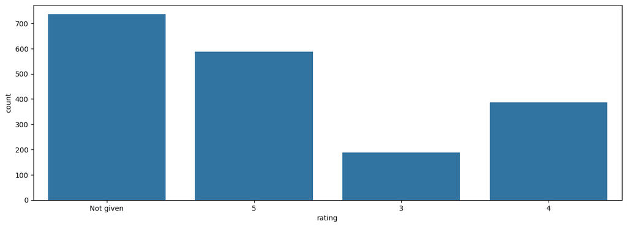

```python
plt.figure(figsize = (15,5))
sns.countplot(data = df, x = 'rating');
```

### Countplot of Rating Observation

#### -- Ratings of 5 and 4 are the most frequently given, indicating a high level of customer satisfaction for many orders.

#### -- Totally 736 orders are "Not given" ratings. This could suggest that some customers choose not to provide feedback or issues with data collection.

#### -- The company could encourage more customers to provide ratings, especially those who leave the "Not given", to gain more complete insights into customer experiences.

#### -- Higher ratings suggests that the overall service is perceived positively by the majority of customers

### 6. Obesetvation on Day of the Week

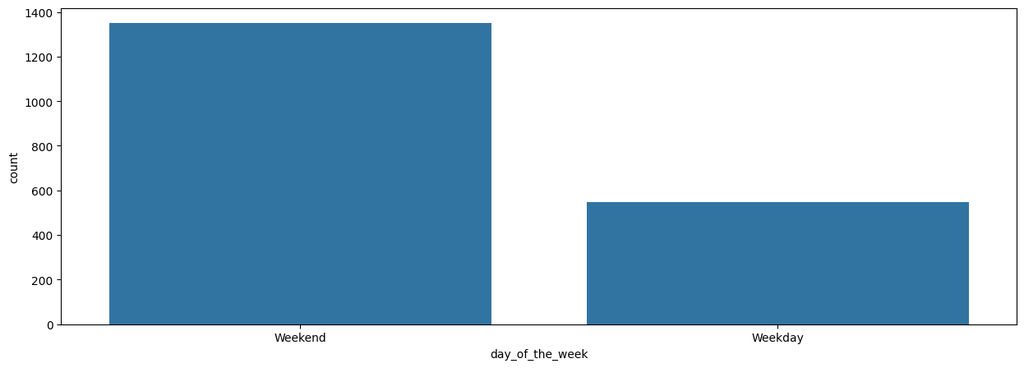

```python
plt.figure(figsize = (15,5))
sns.countplot(data = df, x = 'day_of_the_week');
```

### Counterplot Obesetvation for Week Days/Week Ends

### -- **Higher Order Frequency on Weekends:** The graph shows higher number of orders are placed on weekends compared to weekdays. This suggests that customers are more likely to order food during weekends.

### -- **Lower Order Frequency on Weekdays:** The company can give promotional offers on weekdays to increase orders.

### **Question 7**: Which are the top 5 restaurants in terms of the number of orders received? [1 mark]

```python
df['restaurant_name'].value_counts().head(5)
```

| restaurant_name | count |
| --- | --- |
| Shake Shack | 219 |
| The Meatball Shop | 132 |
| Blue Ribbon Sushi | 119 |
| Blue Ribbon Fried Chicken | 96 |
| Parm | 68 |

**dtype:** int64

### Observations:

### -- The top 5 restaurents in terms of number of orders received are

- Shake Shack
- The Meatball Shop
- Blue Ribbon Sushi
- Blue Ribbon Fried Chicken
- Parm

### **Question 8**: Which is the most popular cuisine on weekends? [1 mark]

```python
# Write the code here
df_weekend = df[df['day_of_the_week'] == 'Weekend']
print(df_weekend['cuisine_type'].value_counts().idxmax())
```

```
American
```

### Observations:

### The most popular cuisine on Weekends is **American**

### **Question 9**: What percentage of the orders cost more than 20 dollars? [2 marks]

```python
# Get orders that cost above 20 dollars
df_ordersabove20 = df[df['cost_of_the_order']>20]
print("The Count of orders that cost above 20 dollars = " , df_ordersabove20.shape[0])
# Calculate percentage of orders that cost above 20 dollars in the dataset
percentage = (df_ordersabove20.shape[0] / df.shape[0]) * 100
print("Percentage of the orders cost more than 20 dollars", percentage)
print("Percentage of the orders cost more than 20 dollars Rounded=", round(percentage, 2), '%')
```

```
The Count of orders that cost above 20 dollars =  555
Percentage of the orders cost more than 20 dollars 29.24130663856691
Percentage of the orders cost more than 20 dollars Rounded= 29.24 %
```

### Observations:

### The Count of orders that cost above 20 dollars = **555**

### Percentage of the orders cost more than 20 dollars = **29.24%**

### **Question 10**: What is the mean order delivery time? [1 mark]

```python
# Write the code here
mean_deltime = df['delivery_time'].mean()
print(f'The mean order delivery time is {round(mean_deltime, 2)} minutes')
```

```
The mean order delivery time is 24.16 minutes
```

### Observations:

### The mean order delivery time is **24.16** minutes

### **Question 11:** The company has decided to give 20% discount vouchers to the top 3 most frequent customers. Find the IDs of these customers and the number of orders they placed. [1 mark]

```python
# Write the code here
df_cust_orders = df.groupby('customer_id')['order_id'].count()
top_five_customer = df_cust_orders.sort_values(ascending=False).head(3)
print(top_five_customer)
```

```
customer_id
52832    13
47440    10
83287     9
Name: order_id, dtype: int64
```

### Observations:

### The top 3 eligible customers for the 20% discount Vouchers are below

### Cust. ID Count

### 52832 13

### 47440 10

### 83287 9

### Multivariate Analysis

### **Question 12**: Perform a multivariate analysis to explore relationships between the important variables in the dataset. (It is a good idea to explore relations between numerical variables as well as relations between numerical and categorical variables) [10 marks]

### 1. Cuisine vs Food Preparation time

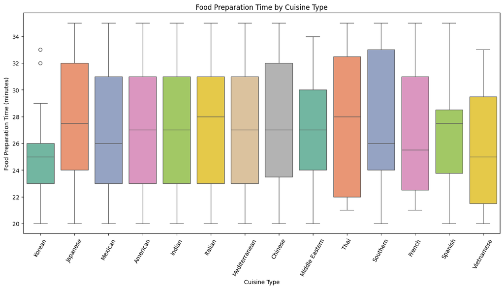

```python
plt.figure(figsize=(15,7))
sns.boxplot(x = "cuisine_type", y = "food_preparation_time", data = df, palette='Set2');
plt.title('Food Preparation Time by Cuisine Type')
plt.xlabel('Cuisine Type')
plt.ylabel('Food Preparation Time (minutes)')
plt.xticks(rotation = 60)
plt.show()
```

### Observations for Cusine vs Food Preparation time

#### -- Better to maintain the consistency for all cuisine preparation time.

### 2. Cuisine vs Cost of the order

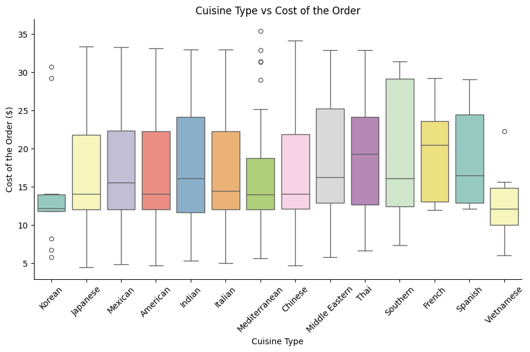

```python
# visualize the relationship between cuisine type and cost of the order using catplot
sns.catplot(x='cuisine_type', y='cost_of_the_order', data=df, kind='box', height=6, aspect=1.5, palette='Set3')
plt.title('Cuisine Type vs Cost of the Order')
plt.xlabel('Cuisine Type')
plt.ylabel('Cost of the Order ($)')
plt.xticks(rotation=45)
plt.tight_layout()
plt.show()
```

### Observations for Cusine vs Cost of the order

#### -- There is noticeable variation in the cost of orders between different cuisine types.

#### -- The lowest cost range for Korean and Vietnamese.

#### -- Outliers found in Korean, Mediterranean and Vietnamese.

#### -- Southem had the highest cost, then followed by Middle Eastern, Indian and Spanish.

#### -- Fresh cuisine has the highest median cost compare to others.

### 3. Day of week vs Delivery Time

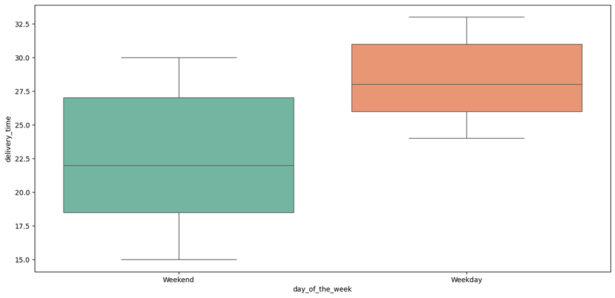

```python
# Relationship between day of the week and delivery time
plt.figure(figsize=(15,7))
sns.boxplot(x='day_of_the_week',y='delivery_time', data = df, palette='Set2' )
plt.show()
```

### 4. Heatmap to know the correlation

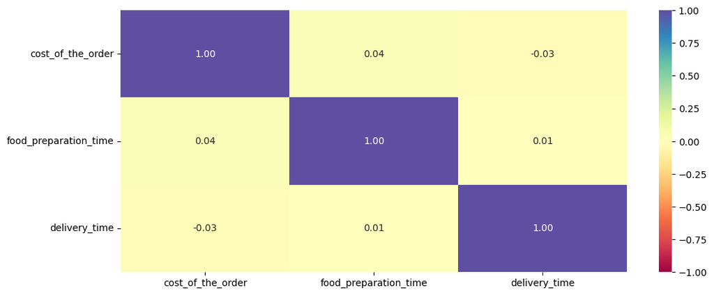

```python
# Plot the heatmap
col_list = ['cost_of_the_order', 'food_preparation_time', 'delivery_time']
plt.figure(figsize=(12, 5))
sns.heatmap(df[col_list].corr(), annot=True, vmin=-1, vmax=1, fmt=".2f", cmap="Spectral")
plt.show()
```

### Observation from Heatmap

#### **Cost of order & Food Preparation Time:** Order of cost do not necessarily result in longer preparation due to weak correlation.

#### **Cost of order & Delivery time:** Cost of order do not necessarily result in longer delivery time due to weak correlation.

### 5. Rating vs Delivery Time

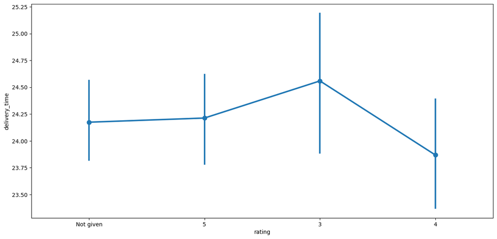

```python
# Relationship between rating and delivery time
plt.figure(figsize=(15, 7))
sns.pointplot(x = 'rating', y = 'delivery_time', data = df)
plt.show()
```

### Observation from Pointplot for Rating vs Delivery Time

The point plot shows the relationship between customer ratings (rating) and average delivery time (delivery_time).

- **High Delivery Time for Rating 3**: The plot shows that orders with a rating of 3 have the highest average delivery time (around 25 minutes). This may suggest that customers tend to give lower ratings when delivery times are longer, or that such orders are inconsistent in terms of timing.
- **Lower Delivery Time for Rating 4**: Orders with a rating of 4 have the shortest average delivery time (around 24 minutes). This may indicate that quicker deliveries lead to higher customer satisfaction.
- **Consistent Delivery Time for Rating 5**: Interestingly, for orders rated 5, the average delivery time is around 24.25 minutes, very close to that of the "Not given" category.
- **Ratings with Not given"**: For the "Not given" category, the average delivery time is around 24.25 minutes, with relatively moderate variability. Most delivery times are close to the average (around 24.25 minutes), some can be a little faster or slower, but the difference isn't too large.

### 6. Rating vs Food Preparation Time

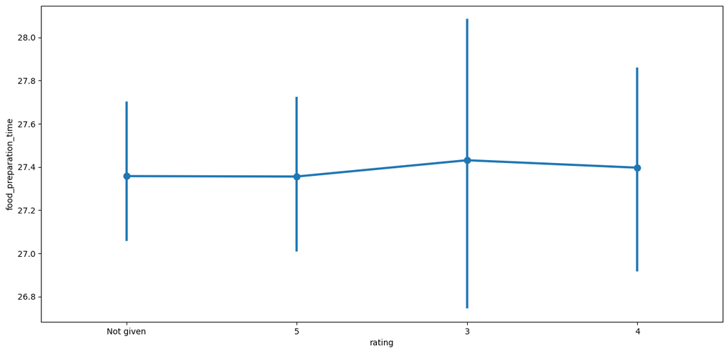

```python
# Relationship between rating and food preparation time
plt.figure(figsize=(15, 7))
sns.pointplot(x = 'rating', y = 'food_preparation_time', data = df)
plt.show()
```

### Observation from Pointplot for Rating vs Food Preparation Time

The point plot shows the relationship between customer ratings (rating) and average food preparation time

- **Consistent Preparation Times for Rating 4 and 5**: The average food preparation time for orders rated 4 and 5 around 27.3 to 27.4 minutes, with smaller variation, suggesting more consistency in preparation times for higher-rated orders.
- **Food Preparation Time for Rating 3**: Orders with a rating of 3 have a slightly higher average preparation time (around 27.45 minutes). Not big difference from the Ratings 4 and 5.
- **Ratings with Not given**: For the "Not given" category, the average food preparation time is around 27.4 minutes.
- **Food preparation can be consistent to get the better rating.**

### 7. Heatmap of Ratings Count by Cuisine Type

```
rating           3    4    5  Not given
cuisine_type
American        64  130  174        216
Chinese         24   40   69         82
French           2    3    5          8
Indian           5   13   32         23
Italian         28   54   90        126
Japanese        40   91  142        197
Korean           2    4    3          4
Mediterranean    9    7   16         14
Mexican          6   16   26         29
Middle Eastern   5   16   13         15
Southern         1    7    5          4
Spanish          0    1    5          6
Thai             0    3    6         10
Vietnamese       2    1    2          2
```

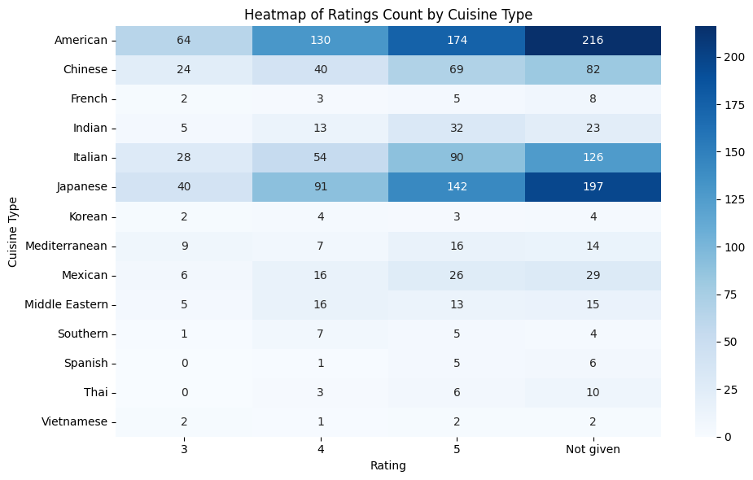

```python
# Heatmap of ratings count by Cuisine
plt.figure(figsize=(10, 6))
rating_cuisine_pivot = df.pivot_table(index='cuisine_type', columns='rating', aggfunc='size', fill_value=0)
print(rating_cuisine_pivot)
sns.heatmap(rating_cuisine_pivot, annot=True, fmt='d', cmap='Blues')
plt.title('Heatmap of Ratings Count by Cuisine Type')
plt.xlabel('Rating')
plt.ylabel('Cuisine Type')
plt.tight_layout()
plt.show()
```

### Obnservations from Heatmap of ratings count by Cuisine

### -- Rate count by cuine types gives clear idea to know which cuisine has high rating and not given.

### -- The Not given count is mostly higher than the 3, 4 & 5 ratings.

### **Question 13:** The company wants to provide a promotional offer in the advertisement of the restaurants. The condition to get the offer is that the restaurants must have a rating count of more than 50 and the average rating should be greater than 4. Find the restaurants fulfilling the criteria to get the promotional offer. [3 marks]

```python
# Write the code here
# Filter the rated restaurents
df_rated = df[df['rating'] != 'Not given'].copy()
# Convert rating column from object to integer due to Not Given value
df_rated['rating'] = df_rated['rating'].astype('int')
# Group the data by 'restaurant_name' to calculate the count and mean of ratings
restaurant_ratings = df_rated.groupby('restaurant_name')['rating'].agg(['count', 'mean'])
# Filter restaurants that have more than 50 ratings and an average rating greater than 4
promotional_restaurants = restaurant_ratings[(restaurant_ratings['count'] > 50) & (restaurant_ratings['mean'] > 4)]
print(promotional_restaurants)
```

```
                           count  mean
restaurant_name
Blue Ribbon Fried Chicken     64 4.328
Blue Ribbon Sushi             73 4.219
Shake Shack                  133 4.278
The Meatball Shop             84 4.512
```

#### Observations:

#### Restaurants that have more than 50 ratings and an average rating greater than 4.

- Blue Ribbon Fried Chicken with count of 64 ratings and an average rating of 4.33
- Blue Ribbon Sushi with the count of 73 ratings and an average rating of 4.21
- Shake Shack with the count of 133 ratings and an average rating of 4.28
- The Meatball Shop with the count of 84 ratings and an average rating of 4.51

### **Question 14:** The company charges the restaurant 25% on the orders having cost greater than 20 dollars and 15% on the orders having cost greater than 5 dollars. Find the net revenue generated by the company across all orders. [3 marks]

```python
#A function to determine the revenue
def compute_rev(x):
    if x > 20:
        return x*0.25
    elif x > 5:
        return x*0.15
    else:
        return x*0

# The Revenue Column calculated and added as per the requirement
df['Revenue'] = df['cost_of_the_order'].apply(compute_rev)
df.head()
```

|  | order_id | customer_id | restaurant_name | cuisine_type | cost_of_the_order | day_of_the_week | rating | food_preparation_time | delivery_time | Revenue |
| --- | --- | --- | --- | --- | --- | --- | --- | --- | --- | --- |
| 0 | 1477147 | 337525 | Hangawi | Korean | 30.750 | Weekend | Not given | 25 | 20 | 7.688 |
| 1 | 1477685 | 358141 | Blue Ribbon Sushi Izakaya | Japanese | 12.080 | Weekend | Not given | 25 | 23 | 1.812 |
| 2 | 1477070 | 66393 | Cafe Habana | Mexican | 12.230 | Weekday | 5 | 23 | 28 | 1.835 |
| 3 | 1477334 | 106968 | Blue Ribbon Fried Chicken | American | 29.200 | Weekend | 3 | 25 | 15 | 7.300 |
| 4 | 1478249 | 76942 | Dirty Bird to Go | American | 11.590 | Weekday | 4 | 25 | 24 | 1.738 |

```python
# Find the total revenue and print it
total_rev = df['Revenue'].sum()
print(f'The net revenue is ${round(total_rev, 2)}')
```

```
The net revenue is $6166.3
```

### Observations

### The total revenue calculated by the company across all the orders is **\$6166.3**

### The company keep doing promotional offers like this[\$5 to \$20] to target customers with orders to encourage more frequent high-value orders, further boosting revenue.

### **Question 15:** The company wants to analyze the total time required to deliver the food. What percentage of orders take more than 60 minutes to get delivered from the time the order is placed? (The food has to be prepared and then delivered.) [2 marks]

```python
# Calculate total delivery time  by adding food_preparation_time and delivery_time, then add a new column to the dataframe to store the total delivery time
df['total_time'] = df['food_preparation_time'] + df['delivery_time']
df.head()
```

|  | order_id | customer_id | restaurant_name | cuisine_type | cost_of_the_order | day_of_the_week | rating | food_preparation_time | delivery_time | Revenue | total_time |
| --- | --- | --- | --- | --- | --- | --- | --- | --- | --- | --- | --- |
| 0 | 1477147 | 337525 | Hangawi | Korean | 30.750 | Weekend | Not given | 25 | 20 | 7.688 | 45 |
| 1 | 1477685 | 358141 | Blue Ribbon Sushi Izakaya | Japanese | 12.080 | Weekend | Not given | 25 | 23 | 1.812 | 48 |
| 2 | 1477070 | 66393 | Cafe Habana | Mexican | 12.230 | Weekday | 5 | 23 | 28 | 1.835 | 51 |
| 3 | 1477334 | 106968 | Blue Ribbon Fried Chicken | American | 29.200 | Weekend | 3 | 25 | 15 | 7.300 | 40 |
| 4 | 1478249 | 76942 | Dirty Bird to Go | American | 11.590 | Weekday | 4 | 25 | 24 | 1.738 | 49 |

```python
# Get orders that take more than 60 dollars
df_ordergreater_than_60 = df[df['total_time']>60]

# Calculate the number of total orders where the time is above 60 minutes
print('The number of total orders that take more than 60 minutes is :', df_ordergreater_than_60.shape[0])

# Calculate percentage of such orders in the dataset
percentage = (df_ordergreater_than_60.shape[0] / df.shape[0]) * 100
print("Percentage of orders take more than 60 minutes:", round(percentage, 2), '%')
```

[output not shown]

### Observations:

### -- 10.54% of total oreder takes more than 60 minutes. The remining 90% of orders takes less than 60 minutes.

### -- A follow-up analysis on the ratings of this more than 60 minutes orders could help assess whether longer delivery times correlate with lower customer ratings or dissatisfaction.

### **Question 16:** The company wants to analyze the delivery time of the orders on weekdays and weekends. How does the mean delivery time vary during weekdays and weekends? [2 marks]

```python
# Get the mean delivery time on weekdays and print it
mean_weekday = df[df['day_of_the_week'] == 'Weekday']['delivery_time'].mean()
print(f'The mean delivery time in week days is {round(mean_weekday, 2)} minutes')

# Get the mean delivery time on weekends and print it
mean_weekend = df[df['day_of_the_week'] == 'Weekend']['delivery_time'].mean()
print(f'The mean delivery time in week ends is {round(mean_weekend, 2)} minutes')
```

```
The mean delivery time in week days is 28.34 minutes
The mean delivery time in week ends is 22.47 minutes
```

### Observations:

### -- The average delivery time on weekends is significantly lower **22.47** minutes compared to weekdays **28.34** minutes. This suggests that orders are being delivered more quickly on weekends.

### Conclusion and Recommendations

### **Question 17:** What are your conclusions from the analysis? What recommendations would you like to share to help improve the business? (You can use cuisine type and feedback ratings to drive your business recommendations.) [6 marks]

### Conclusions:

- **Cuisine Popularity & Unpopularity:** American and Japanese cuisines have the highest demand. These cuisines are a strong contributor to overall business performance.

### Final Thoughts:

- By improving operational efficiency, encouraging customer feedback, guaranteeing fast delivery on weekdays, and focusing on popular and underperforming cuisines, the company can enhance the overall customer experience and better align its offerings with customer preferences. These efforts will likely lead to higher customer satisfaction and stronger business performance across various cuisine types.